# MAM Coagulation Verification Test

## Component Being Tested

Atmosphere, Modal Aerosol Model physics, Coagulation time-stepping

## Description

### Aerosol Modes

The Modal Aerosol Model (MAM) tracks aerosol particles via modes, so that a single distribution of particles over a range of diameters can be described by just three terms: a total number concentration, a median particle diameter, and a standard deviation. The distribution, $n$ of particles of diameter $D_i$, for the $i$th mode, is given by

$$ n(\ln D_i) = \frac{N_{\text{t},i}}{\sqrt{2\pi}\ln\sigma_{\text{g},i}} \ \text{exp}\left[-\frac{1}{2}\frac{(\ln D_i -\ln D_{\text{gn},i})^2}{\ln^2 \sigma_{\text{g},i}}\right], $$

where $N_{\text{t},i}$ is the total number concentration, $\sigma_{\text{g},i}$ is the standard deviation, and $D_{\text{gn},i}$ is the median particle diameter. The subscript $\text{g}$ denotes a geometric quantity, $i$ denotes the $i$th mode, and **MAM tracks three modes**. Note that this equation is a little different than a standard normal distribution, in that the random variable is the $\ln D_i$ rather than $D_i$ itself. Similarly, the effective mean is $\ln D_{\text{gn},i}$ and the effective standard deviation is $\ln \sigma_{\text{g},i}$.

As an example of a single aerosol mode, for a total number concentration $N_{\text{t},i} = 10^8$, a median diameter $D_{\text{gn},i} = 0.2 \times 10^{-6}$m, and a standard deviation $\sigma_{\text{g},i} = 1.8$m, the mode would look like this:

```python
# Import packages:
import numpy
import matplotlib.pyplot as plt
import mam_util
from ResultReporter import ResultWriter, ResultReader
from imp import reload        # This is python 2/3 compatible
```

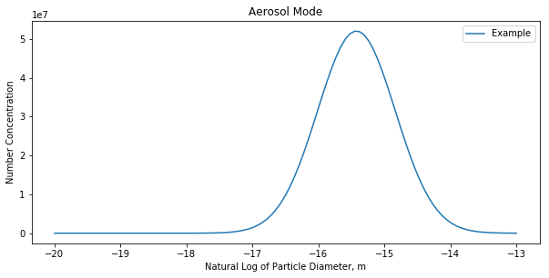

```python
%matplotlib inline
mam_util.plot_single_mode(magnitude=1e8, median=0.2e-6, std_dev=1.8, label="Example")
```

The three modes tracked by MAM are referred to as the *Aitken* mode, the *Accumulation* mode and the *Primary Carbon* mode. Each mode has its own fixed standard deviation, but the total number concentration and median particle diameters can vary over time. A composite of these modes at a typical distribution might look like this:

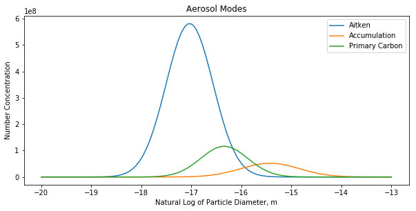

```python
aitken = (1e9, 0.04e-6, 1.6, "Aitken")
accum  = (1e8, 0.20e-6, 1.8, "Accumulation")
pca    = (2e8, 0.08e-6, 1.6, "Primary Carbon")
mam_util.plot_three_modes(aitken, accum, pca)
```

Commonly in MAM, a normalized number distribution is tracked:

$$ n_{\text{norm},i} = \frac{n(\ln D_i)}{N_{\text{t},i}}. $$

### Coagulation Rate Coefficients

Depending on the Knudsen number, different coagulation kernels apply. The Knudsen number is a dimensionless parameter defined by

$$ \mbox{Kn} = \frac{2\lambda}{D}, $$

where $\lambda$ is the mean free path of the fluid surrounding a particle, and $D=\sqrt[3]{D_1^3+D_2^3}$ is the effective diameter of the particle created when two particles of diameter $D_1$ and $D_2$ collide.

$$ \begin{eqnarray} \beta_{nc}(D_1,D_2) &=& 2 \pi\left[\frac{k_\text{B} T C_c}{3\pi\mu D_1} + \frac{k_\text{B} T C_c}{3\pi\mu D_2}\right] (D_1 + D_2), \\ \tilde{\beta}_\text{fm}(D_1,D_2) &=& \left[\frac{3k_\text{B} T}{\rho_\text{p}}\right]^{1/2} \left[D_1^{0.5} + 2\frac{D_2}{D_1^{0.5}} + \frac{D_2^2}{D_1^{1.5}} + \frac{D_1^2}{D_2^{1.5}} + 2\frac{D_1}{D_2^{0.5}}+D_2^{0.5}\right] \end{eqnarray} $$

where $C_c$ is the slip correction factor, $\mu$ is the dynamic viscosity of air, $T$ is temperature (K), and $k_\text{B}$ is the Boltzmann constant. $\beta_\text{nc}(D_1,D_2)$ applies in the near continuum regime $(\mbox{Kn} \le 1)$, and $\beta_\text{fm}(D_1,D_2)$ applies in the free-molecular regime $(\mbox{Kn} > 10)$. For each of these, coagulation rate coefficients for intramodal and intermodal coagulation are calculated from

$$ \begin{eqnarray} B_{0,i,i} &=& \left[\frac{1}{2}\int_0^\infty n_{\text{norm},i} \mbox{d}(D_1) \int_0^\infty \beta(D_1,D_2) n_{\text{norm},i} \mbox{d}(D_2)\right] \\ B_{0,i,j} &=& \left[\int_0^\infty n_{\text{norm},i} \mbox{d}(D_{1}) \int_0^\infty \beta(D_1,D_2) n_{\text{norm},j} \mbox{d}(D_2)\right] \\ B_{3,i,j} &=& \left[\int_0^\infty D_1^3 n_{\text{norm},i} \mbox{d}(D_{1}) \int_0^\infty \beta(D_1,D_2) n_{\text{norm},j} \mbox{d}(D_2)\right] \left[\frac{1}{D_{\text{gn},i}^3 \exp\left[\frac{9}{2} \ln^2\sigma_{\text{g},i}\right]}\right] \end{eqnarray} $$

where the subscripts $0$ and $3$ correspond to zeroth and third moments. Once $B_{k,\text{nc}}$ and $B_{k,\text{fm}}$ are both known, the final coagulation rate coefficient used by MAM is given by the harmonic mean:

$$ B_k = \frac{B_{k,\text{fm}} B_{k,\text{nc}}}{B_{k,\text{fm}} + B_{k,\text{nc}}} $$

### Fuchs Kernel

In the verification test, the MAM coagulation rate coefficient is compared to the coefficient found using the Fuchs kernel:

$$ \beta\left(D_1,D_2\right) = \frac{2\pi(\textbf{D}_1 + \textbf{D}_2)(D_1 + D_2)}{\left(\frac{D_1 + D_2}{D_1 + D_2 + 2(g_1^2 + g_2^2)^{1/2}} + \frac{8(\textbf{D}_1 + \textbf{D}_2)}{(\bar{c}_1^2 + \bar{c}_2^2)^{1/2}(D_1 + D_2)}\right)}, $$

where

$$ \begin{eqnarray} \bar{c}_i &=& \left(\frac{8kT}{\pi m_i}\right)^{1/2} \mbox{m/s} \\ \ell_i &=& \frac{8\textbf{D}_{i}}{\pi \bar{c}_{i}}\mbox{m} \\ g_i &=& \frac{1}{3D_i \ell_i}\left[(D_i + \ell_i)^3 - (D_i^2 + \ell_i^2)^{3/2}\right] - D_{pi} \mbox{m} \\ \textbf{D}_i &=&\frac{kTC_{c_i}}{3\pi \mu D_i} \mbox{m}^2/\mbox{s} \\ C_{c_i} &=& 1+\frac{2\lambda}{D_{pi}}\left[1.257 + 0.4\exp\left(-\frac{1.1D_i}{2\lambda}\right)\right] \end{eqnarray} $$

## Variable Definitions

| Name | Definition |
| --- | --- |
| $C_{c_i}$ | slip correction factor for mode $i$ |
| $D_i$ | Particle diameter for mode $i$. The PDF random variable is $(\ln D_i)$ |
| $D_{\text{gn},i}$ | Mean particle diameter for mode $i$ |
| $D_{pi}$ | *Unknown* |
| $g$ | A subscript denoting geometric quantities |
| $i$ | Mode number |
| $k_\text{B}$ | Boltzmann constant |
| $\mu$ | dynamic viscosity of air |
| $N_{\text{t},i}$ | Total number concentration |
| $n$ | The number distribution of particles of diameter $D_i$ |
| $n_{\text{norm},i}$ | The normailzed number distribution of particles of diameter $D_i$ |
| $\rho_\text{p}$ | *Unknown* |
| $\sigma_{\text{g},i}$ | Standard deviation for mode $i$ |
| $T$ | temperature (K) |

## Discussion

Many of the technical details involved in calculating the MAM coagulation rate coefficients and the tests utilized here can be found in the appendix of [1].

### Initial Conditions

The verification test uses ten different sets of initial number concentrations for the three modes. The sets of initial conditions are described in the following table.

[output not shown]

## Results

This test is set up to build and run the standalone test driver `dd.x` compiled from source code `coag_b1_driver.F90`. It creates output file `coag_delNum_delMass.out`, and this notebook is responsible for postprocessing and analyzing the results.

```python
#Parse output file in preparation for plotting:
reload(mam_util)
result = mam_util.parse_output_file("coag_delNum_delMass.out")
```

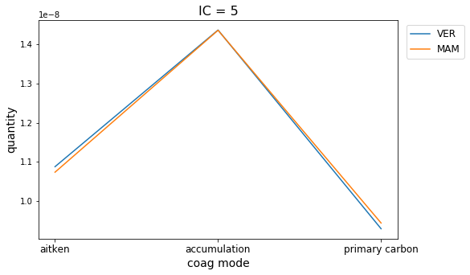

```python
#First plotting example from verification test 2 (MAM vs RK4)

reload(mam_util)

#Set initial condition (1-10):
IC = 5

#Initialize figure and axis:
figure_size = (8,5)
fig, ax  = plt.subplots(1, 1, figsize=figure_size)

#Plot a quantity from the verification solution:
mam_util.plot_quantity_test2(ax=ax, result=result, IC=IC, key="qa(VER,SO4)", label="VER")

#Plot the same quantity from the MAM solution:
mam_util.plot_quantity_test2(ax=ax, result=result, IC=IC, key="qa(MAM,SO4)", label="MAM")

plt.show()
```

```
zero: qa(acc)-SOA
zero: qa(ait)-SOA
zero: qa(pca)-SOA
zero: qa(ait)-POM
```

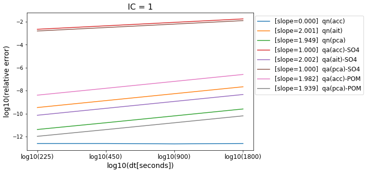

```
zero: qa(acc)-SOA
zero: qa(ait)-SOA
zero: qa(pca)-SOA
zero: qa(ait)-POM
```

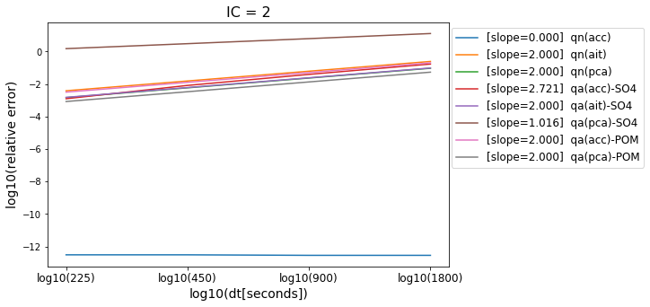

```
zero: qa(acc)-SOA
zero: qa(ait)-SOA
zero: qa(pca)-SOA
zero: qa(ait)-POM
```

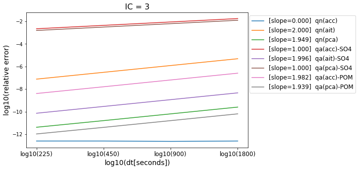

```
zero: qa(acc)-SOA
zero: qa(ait)-SOA
zero: qa(pca)-SOA
zero: qa(ait)-POM
```

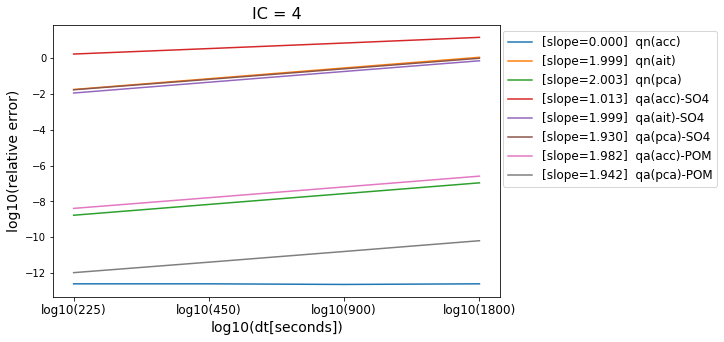

```
zero: qa(acc)-SOA
zero: qa(ait)-SOA
zero: qa(pca)-SOA
zero: qa(ait)-POM
```

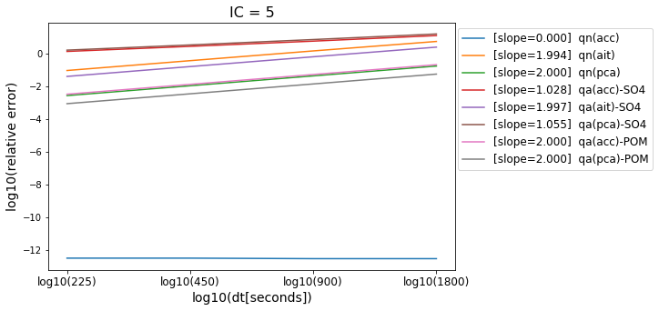

```
zero: qn(ait)
zero: qn(pca)
zero: qa(acc)-SOA
zero: qa(ait)-SOA
zero: qa(pca)-SOA
zero: qa(pca)-SO4
zero: qa(ait)-POM
```

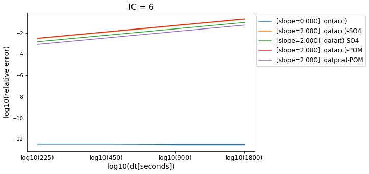

```
zero: qn(acc)
zero: qn(pca)
zero: qa(acc)-SOA
zero: qa(ait)-SOA
zero: qa(pca)-SOA
zero: qa(acc)-SO4
zero: qa(acc)-POM
zero: qa(ait)-POM
zero: qa(pca)-POM
```

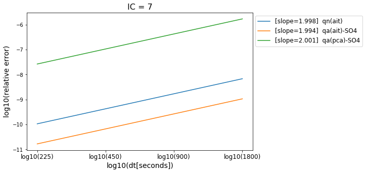

```
zero: qn(ait)
zero: qa(acc)-SOA
zero: qa(ait)-SOA
zero: qa(pca)-SOA
zero: qa(ait)-POM
```

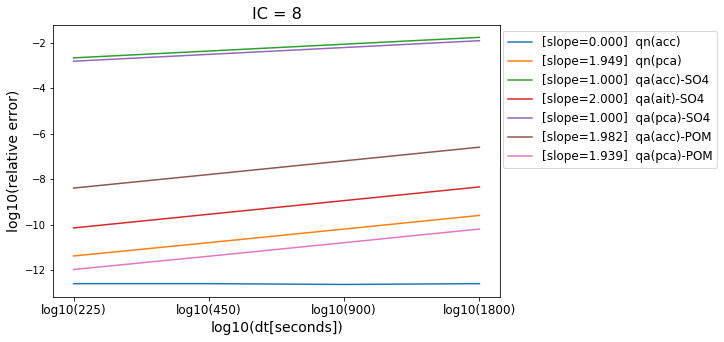

```
zero: qn(pca)
zero: qa(acc)-SOA
zero: qa(ait)-SOA
zero: qa(pca)-SOA
zero: qa(pca)-SO4
zero: qa(ait)-POM
```

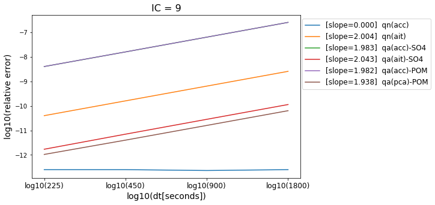

```
zero: qn(acc)
zero: qn(pca)
zero: qa(acc)-SOA
zero: qa(ait)-SOA
zero: qa(pca)-SOA
zero: qa(acc)-SO4
zero: qa(ait)-SO4
zero: qa(pca)-SO4
zero: qa(acc)-POM
zero: qa(ait)-POM
zero: qa(pca)-POM
```

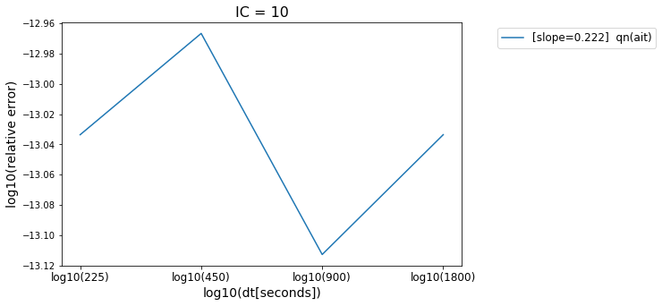

```python
# Second plotting example from verification test 2 (MAM time-split vs RK4)

reload(mam_util)

from ResultReporter import ResultWriter
rw = ResultWriter("coag_results.log")

conv_rates = numpy.zeros((10,12))

# Plot the error (comparing dt=225,450,900,1800 to dt=1):
for IC in range(1,11):
    conv_rates[IC-1,:] = mam_util.plot_errors_test2(figure_size, result, IC)
    for i in range(conv_rates.shape[1]):
        test_name = "IC = %d, %s" % (IC, result["ordered errors"][i])
        if conv_rates[IC-1,i] == 0.0:
            # This happens when errors are machine zero
            test_name += ", TINY errors"
            rw.report_test_passed(test_name)
        else:
            # Convergence rate is finite, check that it is sufficiently large
            test_name += ", slope = %g" % conv_rates[IC-1,i]
            rw.report_test(test_name, conv_rates[IC-1,i] > 0.8)

rw.finished()
```

## References

1. Whitby, E.; McMurry, P.; Shankar, U.; Binkowski, F. Modal aerosol dynamics modeling. **1991**.